# BABS 508 - Team 007

#Team Isha Goyal, Islam Shaalan, Priyanshu Najar, Syed Arsalan Raza

#Setting up the environment and data import

## Loading Employee Attrition Dataset: `attrition_data`

Displaying sample of the dataset

Raw data (first 5 rows)

| EmployeeNumber | Age | BusinessTravel | DailyRate | Department | Education | EducationField | Gender | YearsSinceLastPromotion | YearsWithCurrManager | JobLevel | JobRole | JobSatisfaction | MonthlyIncome | MonthlyRate | PercentSalaryHike | PerformanceRating | TrainingTimesLastYear | WorkLifeBalance | Attrition |
| --- | --- | --- | --- | --- | --- | --- | --- | --- | --- | --- | --- | --- | --- | --- | --- | --- | --- | --- | --- |
| 788 | 34 | Travel_Rarely | 182 | Research & Development | 4 | Life Sciences | Female | 1 | 3 | 1 | Research Scientist | 4 | 3280 | 13551 | 16 | 3 | 2 | 3 | No |
| 789 | 54 | Travel_Rarely | 376 | Research & Development | 4 | Medical | Female | 1 | 4 | 2 | Manufacturing Director | 1 | 5485 | 22670 | 11 | 3 | 4 | 3 | No |
| 790 | 27 | Travel_Frequently | 829 | Sales | 1 | Marketing | Male | 1 | 1 | 2 | Sales Executive | 4 | 4342 | 24008 | 19 | 3 | 3 | 3 | No |
| 791 | 37 | Travel_Rarely | 571 | Research & Development | 1 | Life Sciences | Female | 4 | 3 | 1 | Research Scientist | 1 | 2782 | 19905 | 13 | 3 | 3 | 2 | No |
| 792 | 38 | Travel_Frequently | 240 | Research & Development | 4 | Life Sciences | Female | 4 | 12 | 2 | Manufacturing Director | 1 | 5980 | 26085 | 12 | 3 | 2 | 3 | No |

#Understanding the data

## First we have a look at the data to see what is the data type for each feature and what values does it hold

```
## Rows: 559
## Columns: 20
## $ EmployeeNumber          <dbl> 788, 789, 790, 791, 792, 793, 794, 795, 796, 7…
## $ Age                     <dbl> 34, 54, 27, 37, 38, 34, 35, 30, 40, 34, 42, 24…
## $ BusinessTravel          <chr> "Travel_Rarely", "Travel_Rarely", "Travel_Freq…
## $ DailyRate               <dbl> 182, 376, 829, 571, 240, 121, 384, 921, 791, 1…
## $ Department              <chr> "Research & Development", "Research & Developm…
## $ Education               <dbl> 4, 4, 1, 1, 4, 4, 4, 3, 2, 2, 3, 3, 4, 3, 3, 2…
## $ EducationField          <chr> "Life Sciences", "Medical", "Marketing", "Life…
## $ Gender                  <chr> "Female", "Female", "Male", "Female", "Female"…
## $ YearsSinceLastPromotion <dbl> 1, 1, 1, 4, 4, 1, 0, 0, 3, 1, 14, 0, 1, 0, 3, …
## $ YearsWithCurrManager    <dbl> 3, 4, 1, 3, 12, 3, 2, 2, 7, 2, 9, 0, 4, 3, 7, …
## $ JobLevel                <dbl> 1, 2, 2, 1, 2, 1, 1, 1, 2, 2, 5, 1, 2, 4, 3, 4…
## $ JobRole                 <chr> "Research Scientist", "Manufacturing Director"…
## $ JobSatisfaction         <dbl> 4, 1, 4, 1, 1, 1, 4, 3, 2, 1, 4, 2, 3, 3, 3, 4…
## $ MonthlyIncome           <dbl> 3280, 5485, 4342, 2782, 5980, 4381, 2572, 3833…
## $ MonthlyRate             <dbl> 13551, 22670, 24008, 19905, 26085, 7530, 20317…
## $ PercentSalaryHike       <dbl> 16, 11, 19, 13, 12, 11, 16, 21, 24, 17, 13, 11…
## $ PerformanceRating       <dbl> 3, 3, 3, 3, 3, 3, 3, 4, 4, 3, 3, 3, 4, 3, 3, 3…
## $ TrainingTimesLastYear   <dbl> 2, 4, 3, 3, 2, 3, 1, 2, 2, 1, 4, 4, 3, 3, 3, 3…
## $ WorkLifeBalance         <dbl> 3, 3, 3, 2, 3, 3, 2, 3, 3, 3, 2, 3, 3, 3, 4, 2…
## $ Attrition               <chr> "No", "No", "No", "No", "No", "No", "No", "No"…
```

OK! so some of our variables need re-coding

## Data types and recoding

Now that we have the variables clean and tidy

## Describing the variable

attrition_data  
20 Variables 559 Observations

EmployeeNumber

| n | missing | distinct | Info | Mean | Gmd | .05 | .10 | .25 | .50 | .75 | .90 | .95 |
| --- | --- | --- | --- | --- | --- | --- | --- | --- | --- | --- | --- | --- |
| 559 | 0 | 559 | 1 | 1067 | 186.7 | 815.9 | 843.8 | 927.5 | 1067.0 | 1206.5 | 1290.2 | 1318.1 |

lowest : 788 789 790 791 792 , highest: 1342 1343 1344 1345 1346

Age

| n | missing | distinct | Info | Mean | Gmd | .05 | .10 | .25 | .50 | .75 | .90 | .95 |
| --- | --- | --- | --- | --- | --- | --- | --- | --- | --- | --- | --- | --- |
| 559 | 0 | 43 | 0.999 | 37.32 | 10.55 | 24 | 26 | 30 | 36 | 44 | 51 | 55 |

lowest : 18 19 20 21 22 , highest: 56 57 58 59 60

BusinessTravel

| n | missing | distinct |
| --- | --- | --- |
| 559 | 0 | 3 |

```
 Value             Non-Travel Travel_Frequently     Travel_Rarely
 Frequency                 56               100               403
 Proportion             0.100             0.179             0.721
```

DailyRate

| n | missing | distinct | Info | Mean | Gmd | .05 | .10 | .25 | .50 | .75 | .90 | .95 |
| --- | --- | --- | --- | --- | --- | --- | --- | --- | --- | --- | --- | --- |
| 559 | 0 | 459 | 1 | 796.8 | 466.2 | 167.9 | 235.8 | 458.0 | 819.0 | 1137.5 | 1351.8 | 1425.2 |

lowest : 102 107 109 111 116 , highest: 1485 1490 1492 1495 1498

Department

| n | missing | distinct |
| --- | --- | --- |
| 559 | 0 | 3 |

```
 Value             Human Resources Research & Development                  Sales
 Frequency                      23                    377                    159
 Proportion                  0.041                  0.674                  0.284
```

Education

| n | missing | distinct | Info | Mean | Gmd |
| --- | --- | --- | --- | --- | --- |
| 559 | 0 | 5 | 0.912 | 2.887 | 1.128 |

lowest : 1 2 3 4 5 , highest: 1 2 3 4 5

```
 Value          1     2     3     4     5
 Frequency     71   103   220   148    17
 Proportion 0.127 0.184 0.394 0.265 0.030
```

EducationField

| n | missing | distinct |
| --- | --- | --- |
| 559 | 0 | 6 |

| lowest : | Human Resources | Life Sciences | Marketing | Medical | Other |
| --- | --- | --- | --- | --- | --- |
| highest: | Life Sciences | Marketing | Medical | Other | Technical Degree |

```
 Value       Human Resources    Life Sciences        Marketing          Medical
 Frequency                 7              242               55              168
 Proportion            0.013            0.433            0.098            0.301

 Value                 Other Technical Degree
 Frequency                36               51
 Proportion            0.064            0.091
```

Gender

| n | missing | distinct |
| --- | --- | --- |
| 559 | 0 | 2 |

```
 Value      Female   Male
 Frequency     229    330
 Proportion   0.41   0.59
```

YearsSinceLastPromotion

| n | missing | distinct | Info | Mean | Gmd | .05 | .10 | .25 | .50 | .75 | .90 | .95 |
| --- | --- | --- | --- | --- | --- | --- | --- | --- | --- | --- | --- | --- |
| 559 | 0 | 16 | 0.92 | 2.231 | 3.083 | 0.0 | 0.0 | 0.0 | 1.0 | 3.0 | 7.0 | 10.1 |

lowest : 0 1 2 3 4 , highest: 11 12 13 14 15

```
 Value          0     1     2     3     4     5     6     7     8     9    10    11
 Frequency    225   133    56    20    23    18    13    33     5     4     1     8
 Proportion 0.403 0.238 0.100 0.036 0.041 0.032 0.023 0.059 0.009 0.007 0.002 0.014

 Value         12    13    14    15
 Frequency      2     6     5     7
 Proportion 0.004 0.011 0.009 0.013
```

YearsWithCurrManager

| n | missing | distinct | Info | Mean | Gmd | .05 | .10 | .25 | .50 | .75 | .90 | .95 |
| --- | --- | --- | --- | --- | --- | --- | --- | --- | --- | --- | --- | --- |
| 559 | 0 | 17 | 0.978 | 4.086 | 3.962 | 0 | 0 | 2 | 3 | 7 | 9 | 11 |

lowest : 0 1 2 3 4 , highest: 12 13 14 15 17

```
 Value          0     1     2     3     4     5     6     7     8     9    10    11
 Frequency    100    34   129    64    30    15    10    72    39    24    10     9
 Proportion 0.179 0.061 0.231 0.114 0.054 0.027 0.018 0.129 0.070 0.043 0.018 0.016

 Value         12    13    14    15    17
 Frequency      9     6     2     1     5
 Proportion 0.016 0.011 0.004 0.002 0.009
```

JobLevel

| n | missing | distinct | Info | Mean | Gmd |
| --- | --- | --- | --- | --- | --- |
| 559 | 0 | 5 | 0.905 | 2.116 | 1.232 |

lowest : 1 2 3 4 5 , highest: 1 2 3 4 5

```
 Value          1     2     3     4     5
 Frequency    208   190    79    52    30
 Proportion 0.372 0.340 0.141 0.093 0.054
```

JobRole

| n | missing | distinct |
| --- | --- | --- |
| 559 | 0 | 9 |

| lowest : | Healthcare Representative | Human Resources | Laboratory Technician | Manager | Manufacturing Director |
| --- | --- | --- | --- | --- | --- |
| highest: | Manufacturing Director | Research Director | Research Scientist | Sales Executive | Sales Representative |

Healthcare Representative (49, 0.088), Human Resources (18, 0.032), Laboratory Technician (101, 0.181), Manager (43, 0.077), Manufacturing Director (60, 0.107), Research Director (33, 0.059), Research Scientist (113, 0.202), Sales Executive (117, 0.209), Sales Representative (25, 0.045)

JobSatisfaction

| n | missing | distinct | Info | Mean | Gmd |
| --- | --- | --- | --- | --- | --- |
| 559 | 0 | 4 | 0.931 | 2.669 | 1.246 |

```
 Value          1     2     3     4
 Frequency    123   105   165   166
 Proportion 0.220 0.188 0.295 0.297
```

MonthlyIncome

| n | missing | distinct | Info | Mean | Gmd | .05 | .10 | .25 | .50 | .75 | .90 | .95 |
| --- | --- | --- | --- | --- | --- | --- | --- | --- | --- | --- | --- | --- |
| 559 | 0 | 535 | 1 | 6772 | 5219 | 2106 | 2319 | 2946 | 4841 | 9149 | 16425 | 18218 |

lowest : 1051 1052 1118 1223 1274 , highest: 19845 19847 19859 19943 19973

MonthlyRate

| n | missing | distinct | Info | Mean | Gmd | .05 | .10 | .25 | .50 | .75 | .90 | .95 |
| --- | --- | --- | --- | --- | --- | --- | --- | --- | --- | --- | --- | --- |
| 559 | 0 | 548 | 1 | 14503 | 8234 | 3443 | 4719 | 8318 | 14222 | 20940 | 24061 | 25357 |

lowest : 2243 2253 2261 2323 2326 , highest: 26551 26582 26703 26933 26968

PercentSalaryHike

| n | missing | distinct | Info | Mean | Gmd | .05 | .10 | .25 | .50 | .75 | .90 | .95 |
| --- | --- | --- | --- | --- | --- | --- | --- | --- | --- | --- | --- | --- |
| 559 | 0 | 15 | 0.987 | 15.17 | 3.928 | 11 | 11 | 12 | 14 | 18 | 21 | 22 |

lowest : 11 12 13 14 15 , highest: 21 22 23 24 25

```
 Value         11    12    13    14    15    16    17    18    19    20    21    22
 Frequency     76    71    88    79    34    29    37    39    28    20    17    20
 Proportion 0.136 0.127 0.157 0.141 0.061 0.052 0.066 0.070 0.050 0.036 0.030 0.036

 Value         23    24    25
 Frequency      4    10     7
 Proportion 0.007 0.018 0.013
```

PerformanceRating

| n | missing | distinct | Info | Mean | Gmd |
| --- | --- | --- | --- | --- | --- |
| 559 | 0 | 2 | 0.36 | 3.14 | 0.2406 |

```
 Value         3    4
 Frequency   481   78
 Proportion 0.86 0.14
```

TrainingTimesLastYear

| n | missing | distinct | Info | Mean | Gmd |
| --- | --- | --- | --- | --- | --- |
| 559 | 0 | 7 | 0.909 | 2.78 | 1.367 |

lowest : 0 1 2 3 4 , highest: 2 3 4 5 6

```
 Value          0     1     2     3     4     5     6
 Frequency     24    23   215   179    52    40    26
 Proportion 0.043 0.041 0.385 0.320 0.093 0.072 0.047
```

WorkLifeBalance

| n | missing | distinct | Info | Mean | Gmd |
| --- | --- | --- | --- | --- | --- |
| 559 | 0 | 4 | 0.768 | 2.762 | 0.6981 |

```
 Value          1     2     3     4
 Frequency     27   138   335    59
 Proportion 0.048 0.247 0.599 0.106
```

Attrition

| n | missing | distinct |
| --- | --- | --- |
| 559 | 0 | 2 |

```
 Value          0     1
 Frequency    480    79
 Proportion 0.859 0.141
```

```
## [1] "number of missing rows: 0"
```

Good our data is already clean

Let’s check for any duplicate rows

Since we can have multiple employees with the same conditions the important thing is that we don’t have duplicates of the same employee. So we are checking if there are any duplicated EmployeeNum.

Good we have no duplicate records

We are ready to move on to EDA

#EDA

## Univariate Data

### Attrition variable fill

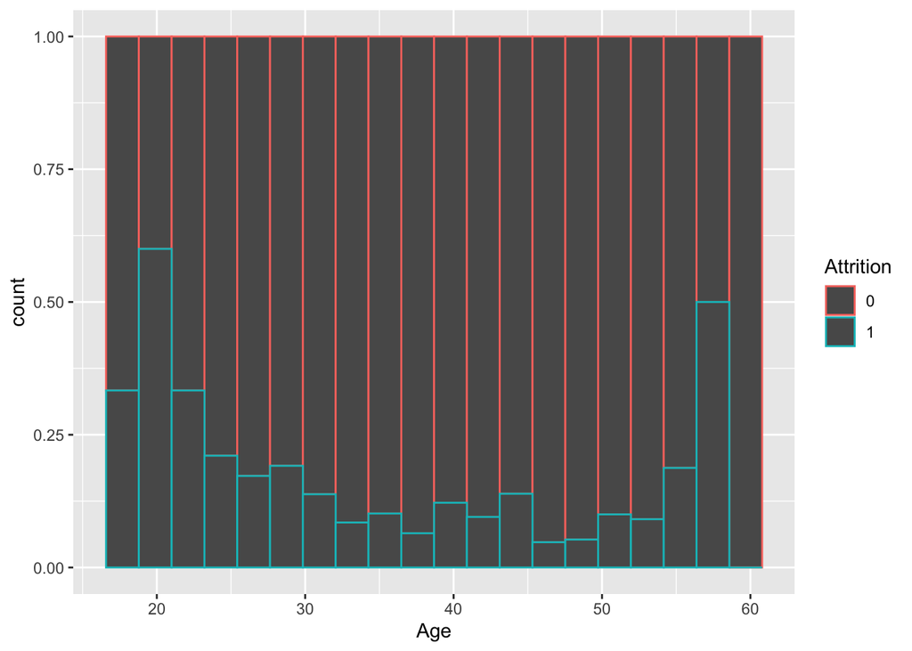

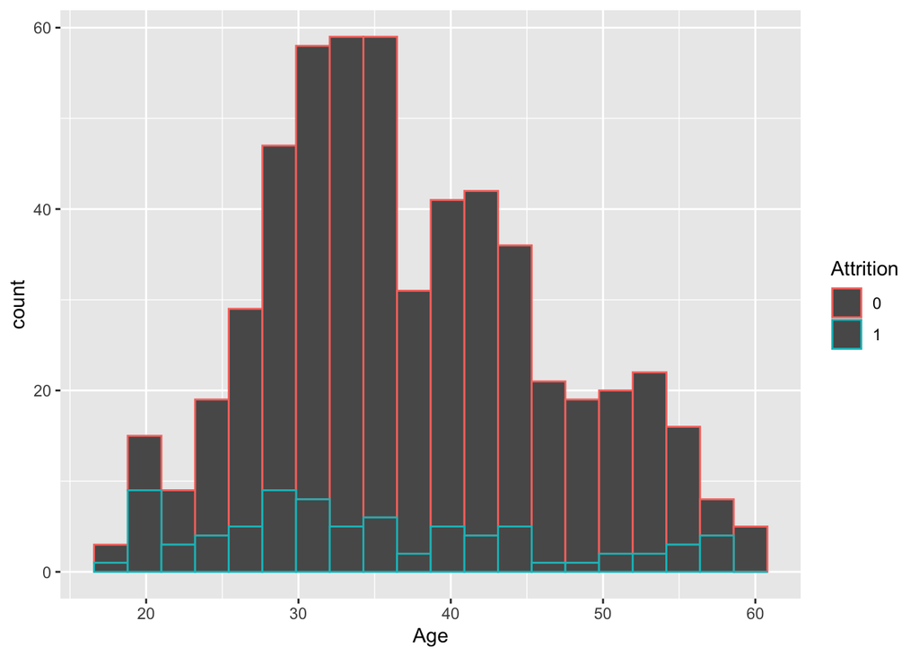

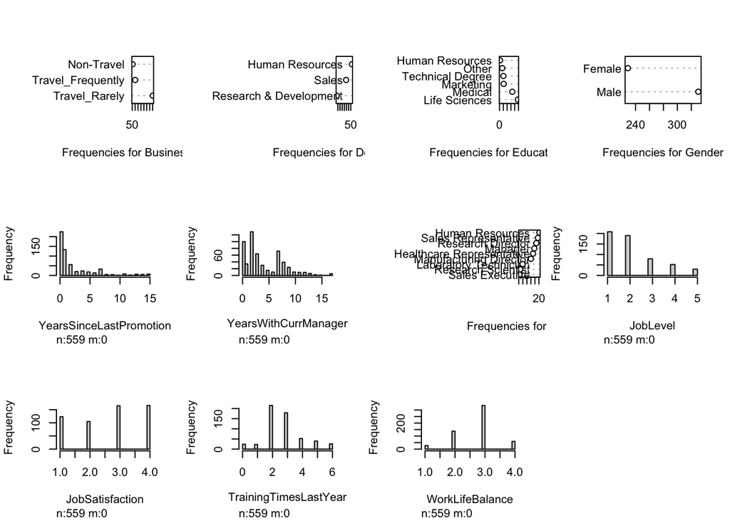

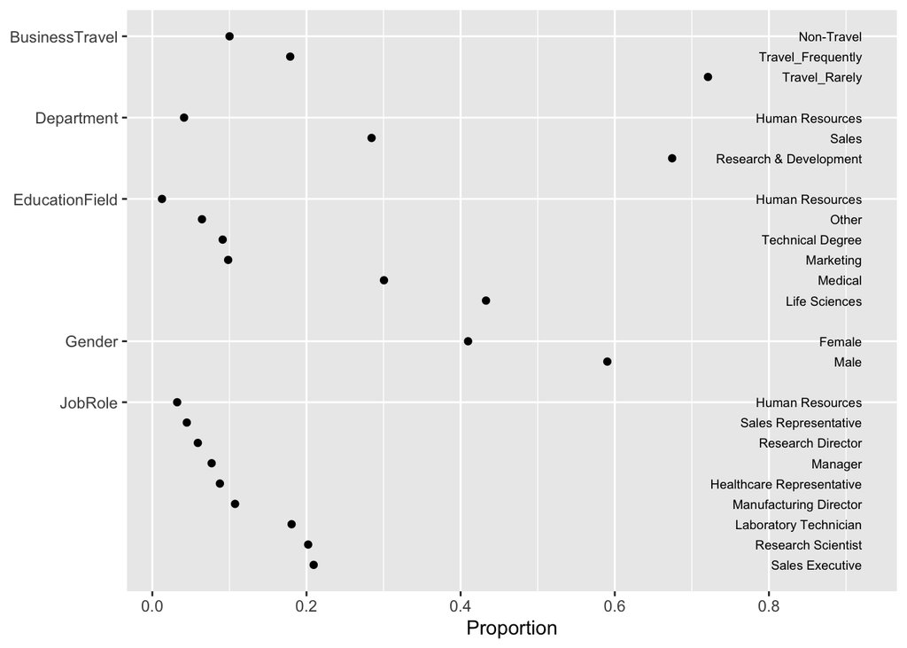

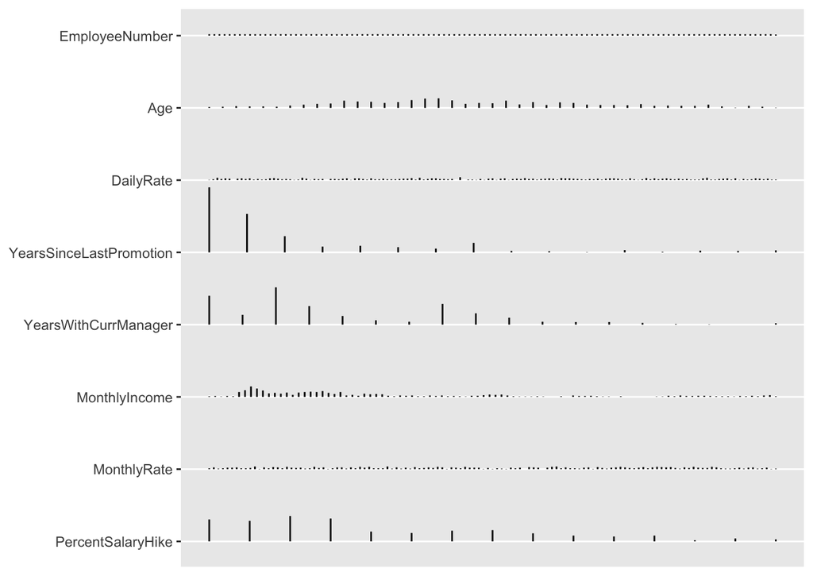

BIVARIATE DATA DISTRIBUTION

```
##          Age
## Attrition 18 19 20 21 22 23 24 25 26 27 28 29 30 31 32 33 34 35 36 37 38 39 40
##         0  2  2  2  2  3  3  7  8  9 15 21 17 19 13 18 22 32 30 23 12 17 13 23
##         1  1  2  4  3  2  1  1  3  5  0  4  5  2  4  2  5  0  3  3  2  0  3  2
##          Age
## Attrition 41 42 43 44 45 46 47 48 49 50 51 52 53 54 55 56 57 58 59 60
##         0 10 19  9 15 16 11  9 10  8 12  6  6  7  7  8  5  1  3  4  1
##         1  2  1  1  4  1  0  1  0  1  1  1  2  0  0  3  0  0  4  0  0
```

```
##          YearsSinceLastPromotion
## Attrition   0   1   2   3   4   5   6   7   8   9  10  11  12  13  14  15
##         0 190 117  48  15  22  16  12  27   5   4   1   6   2   4   5   6
##         1  35  16   8   5   1   2   1   6   0   0   0   2   0   2   0   1
```

```
##          YearsWithCurrManager
## Attrition   0   1   2   3   4   5   6   7   8   9  10  11  12  13  14  15  17
##         0  73  30 111  59  29  13   8  64  34  21   9   8   9   6   0   1   5
##         1  27   4  18   5   1   2   2   8   5   3   1   1   0   0   2   0   0
```

```
##          PercentSalaryHike
## Attrition 11 12 13 14 15 16 17 18 19 20 21 22 23 24 25
##         0 66 62 77 69 28 25 31 35 22 16 15 17  4  7  6
##         1 10  9 11 10  6  4  6  4  6  4  2  3  0  3  1
```

```
##          WorkLifeBalance
## Attrition   1   2   3   4
##         0  18 117 295  50
##         1   9  21  40   9
```

```
##          Gender
## Attrition Female Male
##         0    194  286
##         1     35   44
```

```
##          Education
## Attrition   1   2   3   4   5
##         0  60  90 183 130  17
##         1  11  13  37  18   0
```

```
##          JobRole
## Attrition Healthcare Representative Human Resources Laboratory Technician
##         0                        45              17                    78
##         1                         4               1                    23
##          JobRole
## Attrition Manager Manufacturing Director Research Director Research Scientist
##         0      40                     58                32                 94
##         1       3                      2                 1                 19
##          JobRole
## Attrition Sales Executive Sales Representative
##         0              99                   17
##         1              18                    8
```

```
##          JobLevel
## Attrition   1   2   3   4   5
##         0 161 177  68  48  26
##         1  47  13  11   4   4
```

- Transform Data to correct datatype (DONE)
- Check for duplicates
- univariate exploration
  - Visualize NAs (final_fit or vis_dat) (DONE)
  - histogram
  - Check for outliers
  - Check for inaccurate inputs
- bivariate exploration
  - correlations (vis_cor)
  - histspike data distribution (DONE)
  - scatter plots
  - xtabs (DONE)
- Assumption Testing
  - vif test
- BIAS??
- Model
  - Model validation
  - Interpretation
- Visualization

Shouldn’t we split the data to train and test? Confusion Matrix

| Task | Start Date | End Date | Responsible | Contributer |
| --- | --- | --- | --- | --- |
| Transform Data to correct datatype |  |  |  |  |
| Check for duplicates |  |  |  |  |
| univariate exploration - Visualize NAs (final_fit or vis_dat) - histogram - HIMSC - Check for inaccurate inputs - Check for outliers |  |  |  |  |
| bivariate exploration - correlations (vis_cor) - scatter plot |  |  |  |  |
| Assumption Testing - - - - |  |  |  |  |
| BIAS?? |  |  |  |  |
| Model |  |  |  |  |
| Model validation |  |  |  |  |
| Visualization |  |  |  |  |
| Interpretation |  |  |  |  |